title: “EDA of Trending YouTube Video Statistics” author: “Karra Anand” date: “18 March 2018” output: html_document

## About the dataset

YouTube (the world-famous video sharing website) maintains a list of the top trending videos on the platform. This dataset is a daily record of the top trending YouTube videos.  
This dataset includes several months (and counting) of data on daily trending YouTube videos. Data is included for the USA, with up to 200 listed trending videos per day.  
More details about this dataset are present in `About_datasat.txt` included with this project

## Preprocessing

Before we move on to plotting and analyzing the data, let us see if the data requires any cleaning.  
The first 2 rows of each of the columns of the dataset are as follow:

```
##      video_id trending_date
## 1 2kyS6SvSYSE      17.14.11
## 2 1ZAPwfrtAFY      17.14.11
##                                                            title
## 1                             WE WANT TO TALK ABOUT OUR MARRIAGE
## 2 The Trump Presidency: Last Week Tonight with John Oliver (HBO)
##     channel_title category_id             publish_time
## 1    CaseyNeistat          22 2017-11-13T17:13:01.000Z
## 2 LastWeekTonight          24 2017-11-13T07:30:00.000Z
##                                                                                               tags
## 1                                                                                  SHANtell martin
## 2 last week tonight trump presidency|last week tonight donald trump|john oliver trump|donald trump
##     views likes dislikes comment_count
## 1  748374 57527     2966         15954
## 2 2418783 97185     6146         12703
##                                   thumbnail_link comments_disabled
## 1 https://i.ytimg.com/vi/2kyS6SvSYSE/default.jpg             False
## 2 https://i.ytimg.com/vi/1ZAPwfrtAFY/default.jpg             False
##   ratings_disabled video_error_or_removed
## 1            False                  False
## 2            False                  False
##                                                                                                                                                                                                                                                                                                          …
## 1 SHANTELL'S CHANNEL - https://www.youtube.com/shantellmartin\\nCANDICE - https://www.lovebilly.com\\n\\nfilmed this video in 4k on this -- http://amzn.to/2sTDnRZ\\nwith this lens -- http://amzn.to/2rUJOmD\\nbig drone - http://tinyurl.com/h4ft3oy\\nOTHER GEAR ---  http://amzn.to/2o3GLX5\\nSony CA…
## 2                                                                                                                                                                                                                                                                                                        …
```

> In many of the following data cleaning steps only the code but not the output is printed to prevent repeated printing of the same dataset with minor modifications. The final dataset obtained after the data cleaning is printed at the end of this section.

### Cleaning irrelevant columns

As we are only interested in exploratory analysis of the data, we remove the columns of **tags**, **thumbnail_link** and **description** since they are irrelevant to us.

```
##      video_id trending_date
## 1 2kyS6SvSYSE      17.14.11
## 2 1ZAPwfrtAFY      17.14.11
## 3 5qpjK5DgCt4      17.14.11
## 4 puqaWrEC7tY      17.14.11
## 5 d380meD0W0M      17.14.11
## 6 gHZ1Qz0KiKM      17.14.11
##                                                            title
## 1                             WE WANT TO TALK ABOUT OUR MARRIAGE
## 2 The Trump Presidency: Last Week Tonight with John Oliver (HBO)
## 3          Racist Superman | Rudy Mancuso, King Bach & Lele Pons
## 4                               Nickelback Lyrics: Real or Fake?
## 5                                       I Dare You: GOING BALD!?
## 6                                          2 Weeks with iPhone X
##           channel_title category_id             publish_time   views
```

[output cut: 20 more lines]

```
## [1] 23362    13
```

### Converting into a data.table

From the dimensions of the dataframe in the above output, we have the data for 23,362 videos(assuming there are no duplicates across 13 features; we shall investigate this the following sections). Hence, we use the data.table data structure to store our data as it superior to a dataframe for add, remove, update, join etc. operations.

```r
yt_trending <- data.table(yt_trending)
```

### Adding category names

Further we observe that, we have names of each of the **category_id** (as part of `US_category_id.json` file). Hence, adding the column for **category_name**.

```r
category_id <- c(1,2,10,15,17,18,19,20,21,22,23,24,25,26,27,28,29,30,31,32,33,
                  34,35,36,37,38,39,40,41,42,43,44)
category_name <- c("Film & Animation","Autos & Vehicles","Music",
                    "Pets & Animals","Sports","Short Movies",
                    "Travel & Events","Gaming","Videoblogging",
                    "People & Blogs","Comedy","Entertainment",
                    "News & Politics","Howto & Style","Education",
                    "Science & Technology",
                    "Nonprofits & Activism","Movies","Anime/Animation",
                    "Action/Adventure","Classics","Comedy",
                    "Documentary","Drama","Family","Foreign","Horror",
                    "Sci-Fi/Fantasy","Thriller","Shorts","Shows","Trailers")

category_id_names <- data.frame(category_id,category_name)

yt_trending <- merge(yt_trending,category_id_names)

yt_trending <- yt_trending[order(yt_trending$views,decreasing = TRUE),]
```

### Adding and sorting by days_on_trending

We are most interested here in analyzing the trends in the trending videos, and we do not have a columnn to indicate the number of days a video was on trending, we add that column here.

```r
days_on_trending_video_id <- (count(yt_trending,yt_trending$video_id))[1]
days_on_trending_num_of_days <- (count(yt_trending,yt_trending$video_id))[2]
days_on_trending <- data.table(days_on_trending_video_id,
                               days_on_trending_num_of_days)

setnames(days_on_trending,old="yt_trending$video_id",new="video_id")
setnames(days_on_trending,old="n",new="days_on_trending")

yt_trending <- merge(yt_trending,days_on_trending)

yt_trending <- yt_trending[order(yt_trending$days_on_trending,
                                 yt_trending$views,
                                 decreasing = TRUE),]
```

### Removing duplicate video entries

We sort the videos in decreasing order of their number of days on trending.

```r
yt_trending <- unique(yt_trending, by = c("video_id"))

head(yt_trending)
```

```
##       video_id category_id trending_date
## 1: sXP6vliZIHI          22      18.04.01
## 2: H0g4JxKp4fc          23      18.12.03
## 3: CwKp6Xhy3_4          10      18.12.03
## 4: kCg5D8KMqk4          26      18.07.03
## 5: E_ViwNxUldw          26      18.07.03
## 6: vQiiNGllGQo          15      18.12.03
##                                                         title
## 1: Cardi B - Bartier Cardi (feat. 21 Savage) [Official Audio]
## 2:                                                    *cough*
## 3:                                   Chris Young - Hangin' On
## 4:                                 MY EVERYDAY MAKEUP ROUTINE
## 5:                          Clear crisps / Glass Potato Chips
## 6:              Elderly man making sure his dog won't get wet
##              channel_title             publish_time    views  likes
```

[output cut: 20 more lines]

## Univariate Plots Section

```
## [1] 4712   15
```

```
##  [1] "video_id"               "category_id"
##  [3] "trending_date"          "title"
##  [5] "channel_title"          "publish_time"
##  [7] "views"                  "likes"
##  [9] "dislikes"               "comment_count"
## [11] "comments_disabled"      "ratings_disabled"
## [13] "video_error_or_removed" "category_name"
## [15] "days_on_trending"
```

```
##         video_id     category_id     trending_date
##  00nmxR1mxIA:   1   Min.   : 1.00   18.12.03: 199
##  00RpZZThSAs:   1   1st Qu.:17.00   18.09.01: 141
##  01AEuxSlIMg:   1   Median :24.00   18.01.02:  84
##  02e9klKUN0Y:   1   Mean   :20.44   17.13.12:  70
##  02N508BDngc:   1   3rd Qu.:25.00   17.14.11:  69
##  032BPsxhreM:   1   Max.   :43.00   17.22.11:  68
##  (Other)    :4706                   (Other) :4081
##                                                                                           title
##  DORITOS BLAZE vs. MTN DEW ICE | Super Bowl Commercial with Peter Dinklage and Morgan Freeman:   2
##  Justice League - Movie Review                                                               :   2
##  Maroon 5 - Wait                                                                             :   2
##  Missouri Star Quilt Company Live Stream                                                     :   2
##  NBA Bloopers - The Starters                                                                 :   2
##  Selena Gomez, Marshmello - Wolves                                                           :   2
##  (Other)                                                                                     :4700
##                                 channel_title
##  The Tonight Show Starring Jimmy Fallon:  51
##  ESPN                                  :  46
##  TheEllenShow                          :  44
##  Jimmy Kimmel Live                     :  42
##  Netflix                               :  42
##  The Late Show with Stephen Colbert    :  41
##  (Other)                               :4446
##                    publish_time      views               likes
##  2017-11-17T05:00:00.000Z:   4   Min.   :      559   Min.   :      0
##  2017-11-17T05:00:01.000Z:   3   1st Qu.:    95075   1st Qu.:   1600
##  2017-12-13T15:00:01.000Z:   3   Median :   331606   Median :   7726
##  2018-01-12T05:00:01.000Z:   3   Mean   :  1277663   Mean   :  39715
##  2018-02-16T14:00:03.000Z:   3   3rd Qu.:  1025326   3rd Qu.:  25876
##  2017-11-10T05:00:01.000Z:   2   Max.   :149376127   Max.   :3093544
##  (Other)                 :4694
##     dislikes       comment_count       comments_disabled ratings_disabled
##  Min.   :      0   Min.   :      0.0   False:4633        False:4686
##  1st Qu.:     79   1st Qu.:    238.0   True :  79        True :  26
##  Median :    302   Median :    888.5
##  Mean   :   2598   Mean   :   4975.6
##  3rd Qu.:   1058   3rd Qu.:   2914.2
##  Max.   :1674420   Max.   :1361580.0
##
##  video_error_or_removed         category_name  days_on_trending
##  False:4711             Entertainment  :1141   Min.   : 1.000
##  True :   1             Music          : 585   1st Qu.: 3.000
##                         News & Politics: 438   Median : 5.000
##                         Howto & Style  : 436   Mean   : 4.958
##                         Comedy         : 390   3rd Qu.: 7.000
##                         People & Blogs : 368   Max.   :14.000
##                         (Other)        :1354
```

As we can see from the above output, we have the data of 4,712 videos and their 15 features.

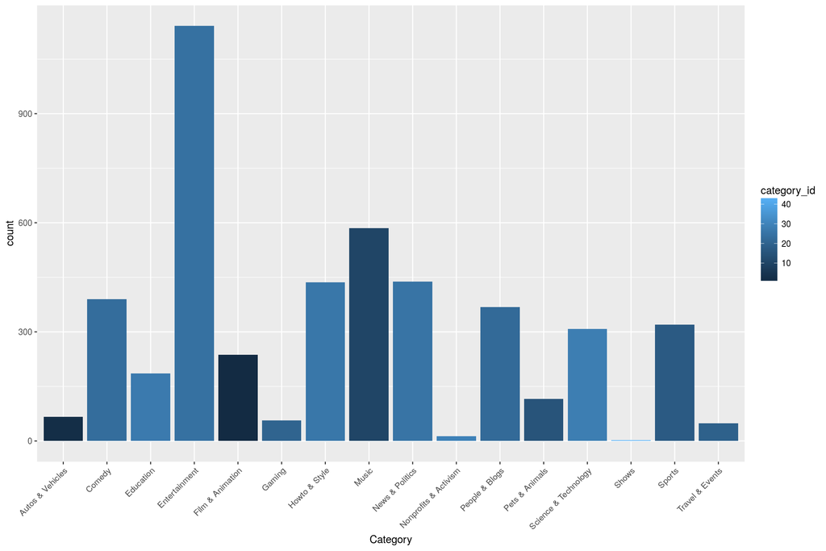

```
##      Action/Adventure       Anime/Animation      Autos & Vehicles
##                     0                     0                    66
##              Classics                Comedy           Documentary
##                     0                   390                     0
##                 Drama             Education         Entertainment
##                     0                   186                  1141
##                Family      Film & Animation               Foreign
##                     0                   237                     0
##                Gaming                Horror         Howto & Style
##                    57                     0                   436
##                Movies                 Music       News & Politics
##                     0                   585                   438
## Nonprofits & Activism        People & Blogs        Pets & Animals
##                    13                   368                   116
##  Science & Technology        Sci-Fi/Fantasy          Short Movies
##                   308                     0                     0
##                Shorts                 Shows                Sports
##                     0                     2                   320
##              Thriller              Trailers       Travel & Events
##                     0                     0                    49
##         Videoblogging
##                     0
```

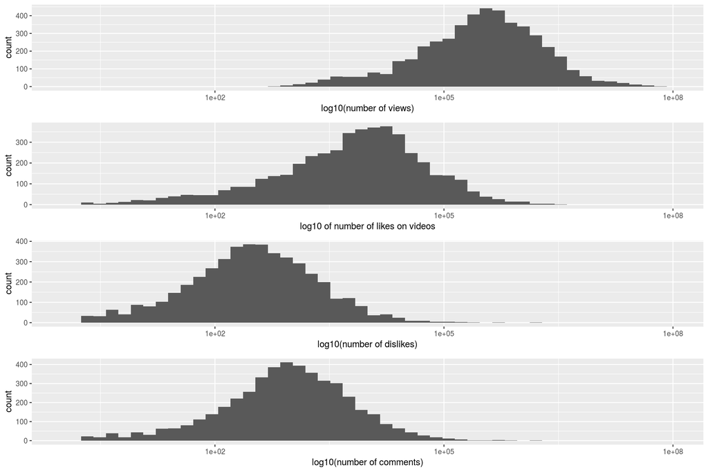

```
## [1] "Summary of views feature:"
```

```
##      Min.   1st Qu.    Median      Mean   3rd Qu.      Max.
##       559     95070    331600   1278000   1025000 149400000
```

```
## [1] "Summary of likes feature:"
```

```
##    Min. 1st Qu.  Median    Mean 3rd Qu.    Max.
##       0    1600    7726   39720   25880 3094000
```

```
## [1] "Summary of dislikes feature:"
```

```
##    Min. 1st Qu.  Median    Mean 3rd Qu.    Max.
##       0      79     302    2598    1058 1674000
```

```
## [1] "Summary of comments feature:"
```

```
##      Min.   1st Qu.    Median      Mean   3rd Qu.      Max.
##       0.0     238.0     888.5    4976.0    2914.0 1362000.0
```

This plot shows the log10 of the number of **views**, **likes**, **dislikes** and **comments** on the videos.  
We can observe a distribution similar to that of a normal distribution. Further, we can see that, the mean number of views is more that that of any other attribute.  
The **mean**, **median** and **maximum** number of view are 1,278,000, 331,600 and 149,400,000 respectively.  
The **mean**, **median** and **maximum** number of likes are 39,720, 7,726 and 3,094,000 repectively.  
The **mean**, **median** and **maximum** number of dislikes are 2,598, 302 and 1,674,000 respectively.  
The **mean**, **median** and **maximum** number of comments are 4,976, 888 and 1,362,000 respectively.

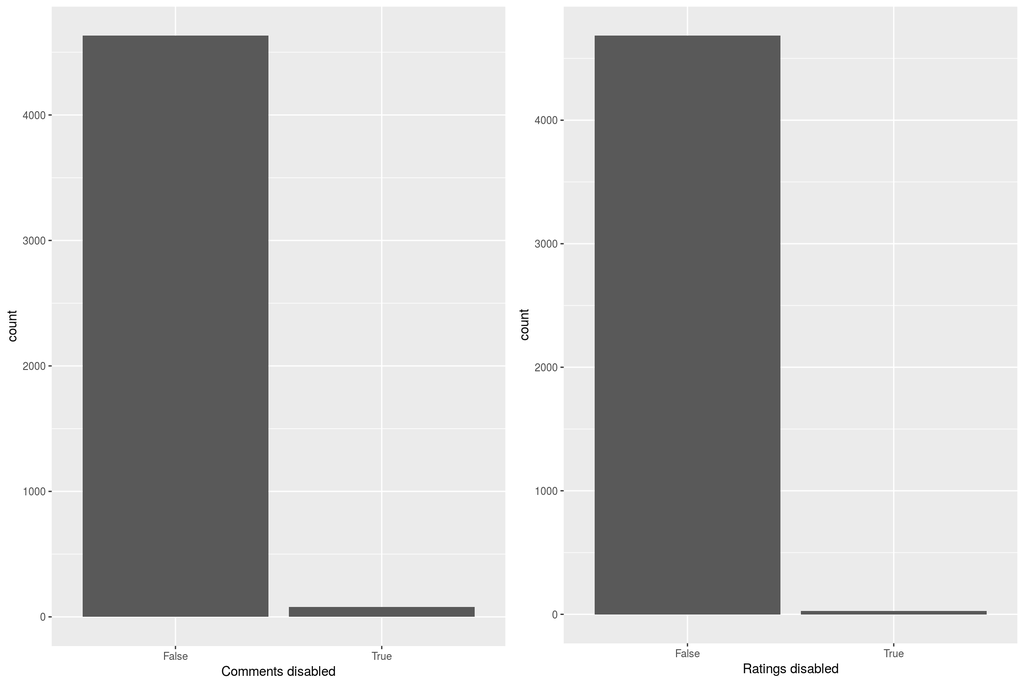

```
## [1] "Summary of videos with comments disabled"
```

```
## False  True
##  4633    79
```

```
## [1] "Summary of videos with ratings disabled"
```

```
## False  True
##  4686    26
```

So we have only 79 videos which have their comments disabled and only 26 videos with their ratings disabled.

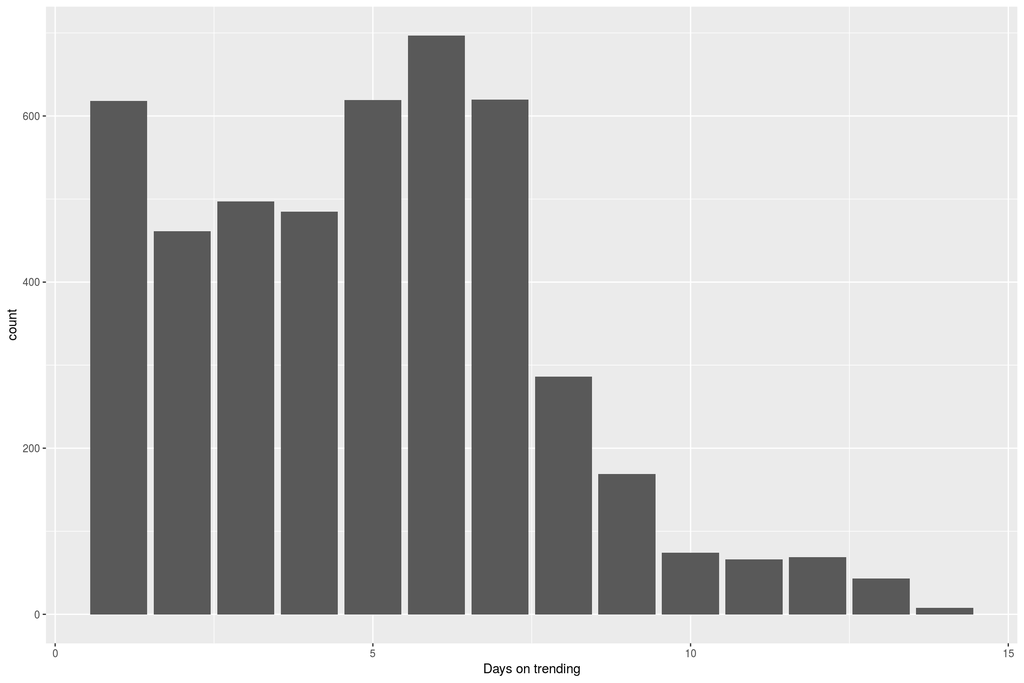

```
##    Min. 1st Qu.  Median    Mean 3rd Qu.    Max.
##   1.000   3.000   5.000   4.958   7.000  14.000
```

We can observe a bimodal type of distribution for the **days on trending**.  
With videos trending for an average of about 5 days and a maximum of 14 days.

### Top 100 trending videos

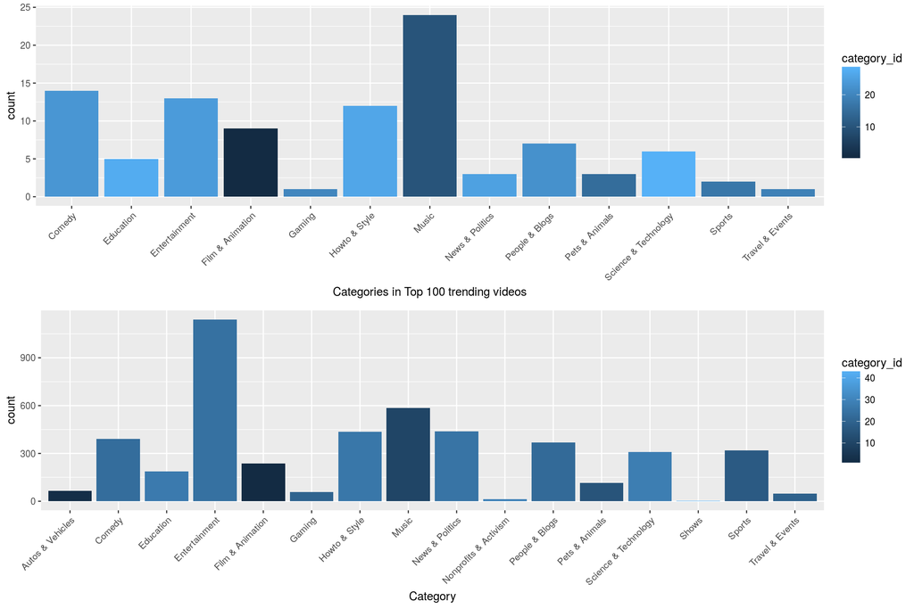

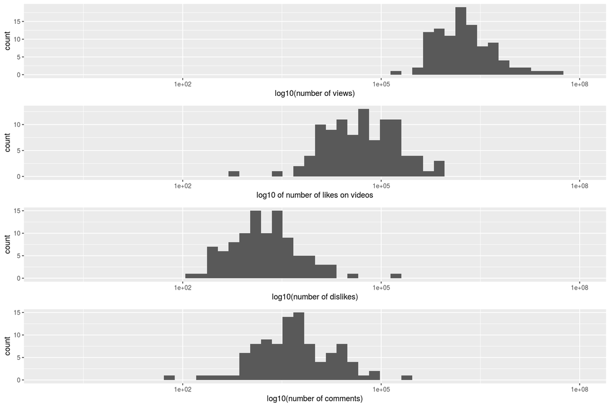

```
## [1] "Summary of views feature:"
```

```
##     Min.  1st Qu.   Median     Mean  3rd Qu.     Max.
##   192400   792100  1665000  3411000  2939000 45940000
```

```
## [1] "Summary of likes feature:"
```

```
##    Min. 1st Qu.  Median    Mean 3rd Qu.    Max.
##     512   19830   49440  105600  131500  822000
```

```
## [1] "Summary of dislikes feature:"
```

```
##     Min.  1st Qu.   Median     Mean  3rd Qu.     Max.
##    146.0    779.2   1600.0   5052.0   3766.0 165100.0
```

```
## [1] "Summary of comments feature:"
```

```
##    Min. 1st Qu.  Median    Mean 3rd Qu.    Max.
##       0    1815    4667   11980   10680  203900
```

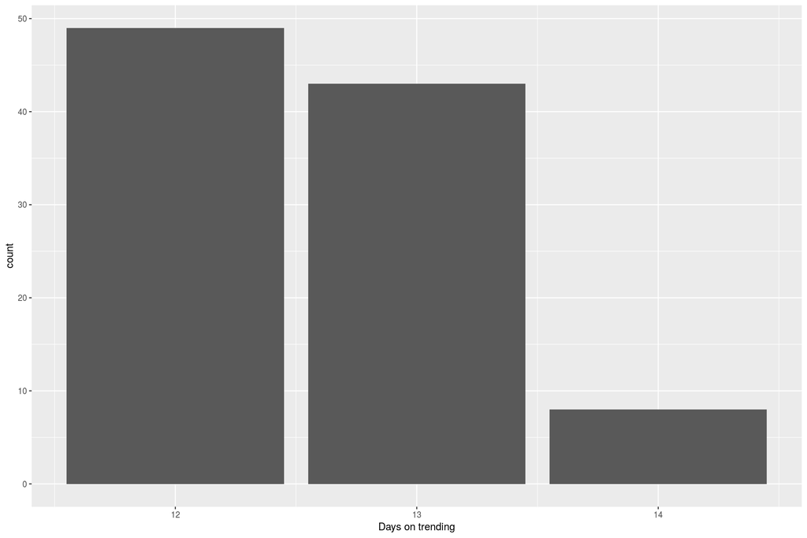

```
##    Min. 1st Qu.  Median    Mean 3rd Qu.    Max.
##   12.00   12.00   13.00   12.59   13.00   14.00
```

Videos in the Top 100 trending videos trend for an average of 13 days with a maximum of 14 days.

## Univariate Analysis

### What is the structure of your dataset?

The dataset after preprocessing to remove duplicates, contains the data for 4712 videos and 15 features (video_id, category_id, trending_date, title, channel_title, publish_time, views, likes, dislikes, comment_count, comments_disabled, ratings_disabled, video_error_or_removed, category_name, days_on_trending)  
**Unordered factors:** category_id, category_name.  
**category_id:** 1,2,10,15,17,18,19,20,21,22,23,24,25,26,27,28,29,30,31,32,33, 34,35,36,37,38,39,40,41,42,43,44  
**category_name:** “Film & Animation”,“Autos & Vehicles”,“Music”, “Pets & Animals”,“Sports”,“Short Movies”, “Travel & Events”,“Gaming”,“Videoblogging”, “People & Blogs”,“Comedy”,“Entertainment”, “News & Politics”,“Howto & Style”,“Education”, “Science & Technology”, “Nonprofits & Activism”,“Movies”,“Anime/Animation”, “Action/Adventure”,“Classics”,“Comedy”, “Documentary”,“Drama”,“Family”,“Foreign”,“Horror”, “Sci-Fi/Fantasy”,“Thriller”,“Shorts”,“Shows”,“Trailers”  
**Other observations:**

### What is/are the main feature(s) of interest in your dataset?

The **number of views (views)**, **number of days the video is trending (days_on_trending)** and **category of the video (category_name)** are the main features of interest here.

### What other features in the dataset do you think will help support your investigation into your feature(s) of interest?

Although subject to the viewers’ biases, number of likes, dislikes and comments can also help in understanding the video’s position on the list of trending videos.

### Did you create any new variables from existing variables in the dataset?

Yes, the variable **category_name** was created to better interpret the category_id feature which has a direct correspondance with category_name.  
Also, the **days_on_trending** variable was created to keep track of the number of days the video was on trending.

### Of the features you investigated, were there any unusual distributions? Did you perform any operations on the data to tidy, adjust, or change the form of the data? If so, why did you do this?

One of the unusual observations were that there were no videos from some of the categories like **Action/Adventure**, **Anime/Animation** etc.

Some features like **tags**, **thubnail_link** and **description** were removed from the dataset as they took a lot of space on printing and were irrelevant to our analysis.

Also, the same video which as trending on nultiple days was reduced to a single entry on the day it had the highest views.